# Visualización: gráficos con ggplot2

Pedro J. Pérez (pedro.j.perez@uv.es). Universitat de València

## 1. Introducción

Los gráficos e infografías son, cada vez más, una parte importante de la mayoría de textos escritos, ya sean estos un informe técnico, un artículo de periódico o un TFG. En el caso de la ciencia de datos, como puede verse abajo en la infografía, el análisis y la exploración de los datos es un proceso iterativo en el que la visualización y la generación de gráficos ocupa un lugar destacado.

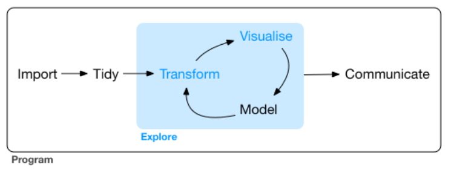

R for Data Science (http://r4ds.had.co.nz/)

Uno de los instrumentos y tareas fundamentales de un científico de datos es la capacidad de realizar visualizaciones de datos apropiadas y convincentes. El análisis gráfico no solo ayuda en la exploración y comprensión de los datos, sino que es fundamental a la hora de mostrar las posibles relaciones entre variables, descubrir relaciones o patrones ocultos, y descartar o sugerir nuevas preguntas sobre los datos.

El entorno R tiene diversos sistemas para visualizar datos, los dos más utilizados son el sistema gráfico de R-base y el ecosistema asociado al paquete `ggplot2`. Por diversas razones, en el curso usaremos el entorno `ggplot2` para hacer nuestros gráficos; de hecho, en la actualidad `ggplot2`, dada su rapidez en la iteración entre gráficos, versatilidad y la cuidada estética que tienen sus gráficos, se ha convertido, al menos por el momento, en el sistema estándar para hacer gráficos en R. Por ejemplo, [¿cómo creéis que hace la BBC sus gráficos?](https://medium.com/bbc-visual-and-data-journalism/how-the-bbc-visual-and-data-journalism-team-works-with-graphics-in-r-ed0b35693535), evidentemente con R y `ggplot2`. Puedes ver uno de sus repositorios [aquí](https://github.com/bbc/bbplot) y su cookbook [aquí](http://bit.ly/bbcggplot2).

Con `ggplot2` es sencillo hacer gráficos con calidad para ser publicados o mostrados, además de que, dada su sintaxis modular, hace sencillo el reutilizar los gráficos durante el proceso de análisis. El paquete `ggplot2` fue inicialmente desarrollado por [Hadley Wickham](http://hadley.nz/), pero actualmente el ecosistema ggplot es el resultado de toda una comunidad de usuarios que contribuye a enriquecer el sistema gráfico con sus extensiones y paquetes auxiliares.

En palabras de Hadley en su [libro sobre ggplot2](https://ggplot2-book.org/):

> ggplot2 is an R package for producing statistical, or data, graphics, but it is unlike most other graphics packages because it has a deep underlying grammar. This grammar, based on the Grammar of Graphics (Wilkinson 2005), is made up of a set of independent components that can be composed in many different ways. This makes ggplot2 very powerful because you are not limited to a set of pre-specified graphics, but you can create new graphics that are precisely tailored for your problem. This may sound overwhelming, but **because there is a simple set of core principles and very few special cases, ggplot2 is also easy to learn** (although it may take a little time to forget your preconceptions from other graphics tools).

Sí, con `ggplot2` es “fácil” hacer rápidamente gráficos de calidad, PERO dominar todos los detalles del paquete sí que es complicado, pero no nos hace falta conocerlo todo. Además, hay que tener en cuenta que `ggplot2` es un paquete/entorno en constante evolución. Actualmente está en la versión 3.2.1. Bueno, en marzo de 2020 apareció la versión 3.3.0.

Para entender esta idea de la constante evolución y el papel que tiene la comunidad de usuarios en el desarrollo de R y sus paquetes puedes leer [este tweet](https://twitter.com/ClausWilke/status/1166356210783870976) y las respuestas a él. En el tweet sólo se anuncia una pequeña mejora en como `ggplot2` gestiona los títulos de los gráficos pero genera reacciones en la comunidad de usuarios.

La redes sociales pueden hacerse eco de la evolución de un paquete, pero donde habitualmente se produce la discusión/colaboración entre usuarios es en plataformas como [Github](https://github.com/). Por ejemplo, puedes ver como se gestó está pequeña mejora [aquí](https://github.com/tidyverse/ggplot2/issues/3252). Fue la issue 3252 de `ggplot2`. Otro ejemplo, justo cuando estaba escribiendo este párrafo, leí [este otro tweet](https://twitter.com/thomasp85/status/1166609529771102208) anunciando otra mejora en `ggplot2`.

La página web de `ggplot2` puedes encontrarla [aquí](https://ggplot2.tidyverse.org/). En ella puedes encontrar documentos de ayuda y la [referencia oficial](https://ggplot2.tidyverse.org/reference/index.html). Para darte cuenta de todo lo que se puede hacer con el ecosistema ggplot visita [esta página](https://exts.ggplot2.tidyverse.org/gallery/) donde podrás ver los 79 “paquetes auxiliares” o extensiones a `ggplot2`.

Para hacer “buenos” gráficos con `ggplot2`no sólo es necesario entender la sintaxis y los pormenores del paquete, sino que quizás se necesite algo más. Por ejemplo, algo de experiencia y cierta capacidad visual y estética; incluso hay quien dice que hacer buenos gráficos es un arte. Para intentar mejorar vuestros gráficos o evitar ciertos errores, [aquí](https://robjhyndman.com/hyndsight/graphics/) tenéis algunas reglas/consejos, y [aquí](https://www.r-bloggers.com/teaching-and-learning-materials-for-data-visualization/) un curso completo sobre visualización[^1] con [bookdown incluido](https://serialmentor.com/dataviz/).

Entenderás muy bien que hacer buenos gráficos exige conocimiento y mucho trabajo al ver el video de [este post](https://karaman.is/blog/2020/07/making-of/), donde se ven las versiones previas para que al final saliese esta preciosura de gŕafico:

> [@LeTour](https://twitter.com/LeTour?ref_src=twsrc%5Etfw) for this [#TidyTuesday](https://twitter.com/hashtag/TidyTuesday?src=hash&ref_src=twsrc%5Etfw). I recreated and adapted the main plot from [@ffranchi](https://twitter.com/ffranchi?ref_src=twsrc%5Etfw)'s great infographic: https://t.co/qLZgLS6jUo  
> code and big image: https://t.co/ns6qngDdJX[#dataviz](https://twitter.com/hashtag/dataviz?src=hash&ref_src=twsrc%5Etfw) [#rstats](https://twitter.com/hashtag/rstats?src=hash&ref_src=twsrc%5Etfw) [pic.twitter.com/DKSYks4j1v](https://t.co/DKSYks4j1v)

> — Georgios Karamanis (@geokaramanis) [April 7, 2020](https://twitter.com/geokaramanis/status/1247586395876741120?ref_src=twsrc%5Etfw)

Otro ejemplo del making-of de un gráfico puedes verlo [aquí](https://twitter.com/MaiaPelletier/status/1287922855926214657).

Otros dos libros sobre visualización con el código de los ejemplos hechos con `ggplot2`, [aquí](https://socviz.co/index.html#preface) y [aquí](https://socviz.co/lookatdata.html#lookatdata). Finalmente, algunos consejos de la [BBC](https://bbc.github.io/rcookbook/) sobre visualización.

Como también se aprende los errores, [aquí](https://medium.economist.com/mistakes-weve-drawn-a-few-8cdd8a42d368) tienes un articulo de The Economist donde muestran errores que ellos mismos han cometido haciendo gráficos. Además pueden descargarse los datos.

## 2. Ideas básicas sobre ggplot2

Ya se dijo que `ggplot2` es un paquete R desarrollado por Hadley Wickham, aunque actualmente es el resultado de la colaboración de múltiples desarrolladores. `ggplot2` implementa en R [The Grammar of Graphics](https://www.springer.com/gp/book/9780387245447) de L. Wilkinson, un sistema coherente para describir y construir gráficos. El énfasis de ggplot2 está en la exploración rápida de datos, especialmente de datos de alta dimensionalidad. Con `ggplot2` es sencillo ir transformando el gráfico mientras se van analizando los datos.

Pues, una de las principales ideas para entender `ggplot2` es que cada capa de un gráfico tiene 3 componentes o elementos principales:

- **los datos** que se van a representar (sencillo, para hacer un gráfico hacen falta datos). Para ello utilizaremos generalmente la función `ggplot()`
- **un conjunto de propiedades estéticas asociadas a alguna variable del conjunto de datos**. Por ejemplo, la variable Sepal.Lenght está asociada al eje X, ala posición en el eje X. Por su parte, el color de los puntos (otra característica visual o estética) está asociado a los valores de la variable Species. Es decir, usando la terminología de `ggplot2`, las distintas variables están asociadas o mapeadas a determinadas características estéticas. El mapeo de variables con estéticas se hará con la función `aes()` de **aes**thetics. (esto ya no es tan estándar, se explica en breve)
- **el elemento geométrico que se va a representar**. En nuestro caso el elemento geométrico que se utiliza para representar los valores de las variables son los puntos, pero podrían haber sido las lineas o las barras … Para especificar el elemento geométrico que vamos a usar en nuestro gráfico se utiliza la familia de funciones `geom_xx()`; por ejemplo `geom_point()` si queremos puntos, `geom_line()` si queremos que las relaciones entre las variables se representen/visualicen como lineas.

Así en abstracto puede ser complicado entender del todo que quiere decir todo esto. Vamos a verlo con ejemplos concretos. De momento, para explicar las principales características de `ggplot2` utilizaré un conjunto de datos famoso, pero odiado por algunos, por haber sido utilizado en numerosos ejemplos y cursos: el [iris dataset](https://es.wikipedia.org/wiki/Conjunto_de_datos_flor_iris).

**PRIMER GRÁFICO**: Para comenzar nuestras andanzas con `ggplot2` intentaremos replicar con código R el gráfico de arriba; aunque al principio sólo utilizaremos 2 variables: haremos un gráfico de puntos de la longitud del sépalo frente a la longitud del pétalo.

Hacer un gráfico con `ggplot2` requiere de varias etapas,

- la primera de ellas consiste en usar la función `ggplot()` para inicializar el gráfico.
- en segundo lugar, tendremos que especificar que conjunto de datos usaremos en el gráfico.
- en tercer lugar tendremos que especificar que variables irán asociadas a determinados elementos visuales o estéticos del gráfico
- por último, en cuarto lugar, tendremos que especificar que tipo de gráfico o geometría usaremos para visualizar las observaciones.

Veámoslo más detenidamente.

En `ggplot2`, para hacer un gráfico **se empieza SIEMPRE llamando a la función `ggplot()`**. Si tecleamos `ggplot()` en la consola o en un script, parece que no ocurre nada, pero tras la llamada a la función `ggplot()`, R ha creado un objeto, un contenedor para nuestro futuro gráfico. Aún no vemos el gráfico, faltan cosas, pero ya lo hemos inicializado. Si quieres ver el objeto/contenedor que hemos creado con la llamada a `ggplot()` tienes que asignarle un nombre, así podrás verlo en la pestaña “Environment” de RStudio.

Para verlo tienes que hacer:

```r
my_grafico <- ggplot()
```

`my_grafico`, es un objeto R, concretamente una lista con 9 elementos, que tendremos que ir “llenando” para hacer nuestro gráfico.

Generalmente, dentro de la función `ggplot()` se suele especificar el conjunto de datos que vas a utilizar para hacer el gráfico. A diferencia de los gráficos de R-base, `ggplot2` no permite graficar vectores: **los datos que se suministran han de ser SIEMPRE data.frames** o similares.

```r
ggplot(data = iris)
ggplot(iris)
```

Ya está, con cualquiera de las 2 instrucciones de arriba, son equivalentes[^2], ya hemos inicializado el gráfico y le hemos dicho que datos vamos a usar.

Dijimos que para comenzar haríamos un gráfico de puntos de la variable `Sepal.Length` frente a `Petal.Length`; así que **tenemos que decirle a `ggplot2` que variables de `iris` queremos visualizar y con que propiedades estéticas queremos asociar cada variable**. Para ello utilizaremos la función `aes()` dentro de `ggplot()`. Lo hacemos con la siguiente expresión:

```r
ggplot(iris, aes(x = Sepal.Length,  y = Petal.Length))
```

Aún no vemos el gráfico, pero con `aes()` le hemos dicho a R/ggplot2 que queremos asociar/mapear la variable Sepal.Length al eje x, y la variable Petal.Length al eje y. Fíjate que, en la pestaña de gráficos de RStudio, ya vemos los ejes del gráfico; además, fíjate que `ggplot2` ya ha calculado para nosotros el rango de las variables para ajustar los ejes.

Al igual que antes, podemos omitir los nombres de las opciones de la función `aes()`. Esta función puede tener muchos argumentos (veremos algunos), pero los 2 primeros son siempre x (el eje x) y después y (el eje y o vertical de mi gráfico); es decir podríamos hacer lo siguiente que es más rápido de teclear.

```r
ggplot(iris, aes(Sepal.Length, Petal.Length))
```

Con esta instrucción le estamos diciendo a `ggplot2` que vamos a hacer un gráfico con los datos del data.frame `iris` y que vamos a asociar/conectar/mapear la variable `Sepal.Length` con el eje x, y la variable `Petal.Length` con el eje y del gráfico. Perfecto, pero entonces ¿por qué no vemos el gráfico? La razón estriba en que no le hemos dicho a `ggplot2` qué tipo de gráfico queremos (de puntos, de lineas etc…). El tipo de gráfico se explicita con una familia de funciones: `geom_xx()` o **geom**etrías. Hay muchas geometrías o tipos de gráficos que podemos usar. Ya lo veremos!!! Nosotros queremos hacer un gráfico de puntos, así que, de la familia de **geom**etrías tenemos que usar `geom_point()`. Veámoslo.

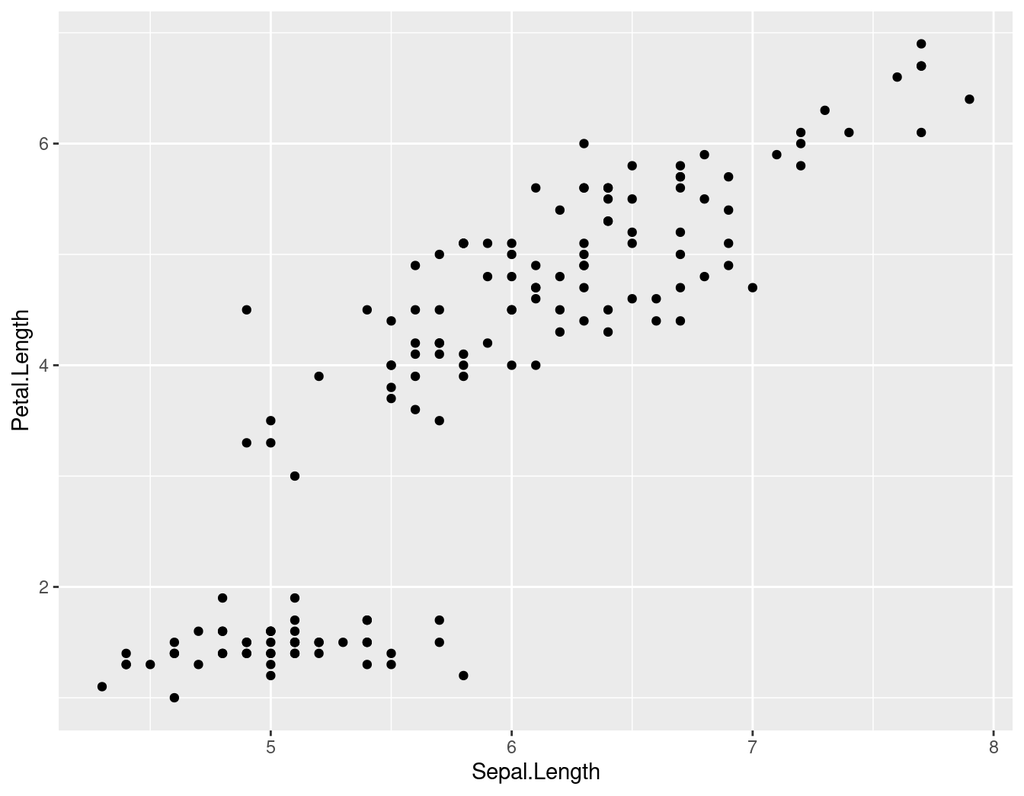

```r
ggplot(iris, aes(Sepal.Length, Petal.Length)) + geom_point()
```

Como vemos los puntos del gráfico se visualizan en color negro, con un tamaño, una transparencia y una forma determinadas. Obviamente todo esto se puede cambiar dentro de `geom_point()` con las opciones adecuadas. Por ejemplo:

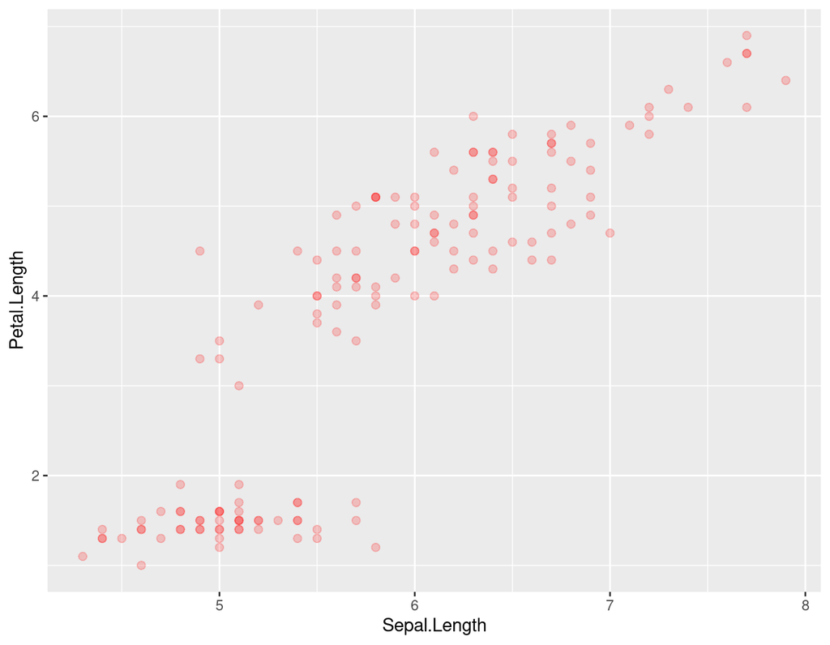

```r
ggplot(iris, aes(Sepal.Length, Petal.Length)) + geom_point(color = "red", size = 2, alpha = 0.2)
```

Ya casi está. No es tan complicado. Ya hemos visto las ideas fundamentales de la visualización con `ggplot2`:

1. Los gráficos se inician con la función `ggplot()`. Generalmente aquí se especifican los datos (data.frame) que queremos utilizar
2. La función `aes()` sirve para asociar/mappear variables con atributos/características estéticas del gráfico. De hecho el nombre del función `aes()` viene de **aes**thetics. Las **aes**thetics más importantes de un gráfico suelen ser los ejes x e y, por eso se ponen siempre al principio de `aes()`; es decir, son los 2 primeros argumentos de `aes()`. En nuestro ejemplo hemos asociado la variable `Sepal.Length` con el eje x, y la variable `Petal.Length` con el eje y. Veremos más **aes**thetics, como por ejemplo el color o el tamaño (de los puntos … o de las lineas o …)
3. Con `geom_**()` elegimos el tipo o **geom**etría de gráfico. Hay muchos tipos de gráficos, así que habrán muchos **geoms**. Por ejemplo: geom_point(), geom_line(), geom_ …

Estas 3 ideas son las principales para entender ggplot2. Después hay muchas más opciones y elementos que serán muy importantes para conseguir un buen gráfico, pero en cierta forma son secundarias; por ejemplo, los títulos, los ejes, las escalas, el tema etc… lo iremos viendo poco a poco.

Afiancemos las ideas principales de la visualización con `ggplot2`. ¿Piensa que hará la siguiente linea de código?

```r
ggplot(iris, aes(Sepal.Length, Petal.Length)) + geom_line()
```

La primera parte de la instrucción es igual a la anterior: queremos un gráfico con el data.frame iris y queremos asociar la variable Sepal.Length con el eje x, con la propiedad **aes**thetic eje x y Petal.Length con el eje y; pero le hemos pedido un gráfico de lineas (geom_line()). En este caso hacer un gráfico de lineas no tiene mucho sentido, pero si se lo pedimos a R, este nos hace caso y nos lo muestra.

[figure not shown]

Ya dije que una de las características importantes de `ggplot2` es que funciona por capas que se van superponiendo; para ir añadiendo capas a nuestro gráfico tenemos que usar el símbolo **`+`**. Por ejemplo si quisiéramos ver los puntos y las lineas ¿Cómo lo hacemos?

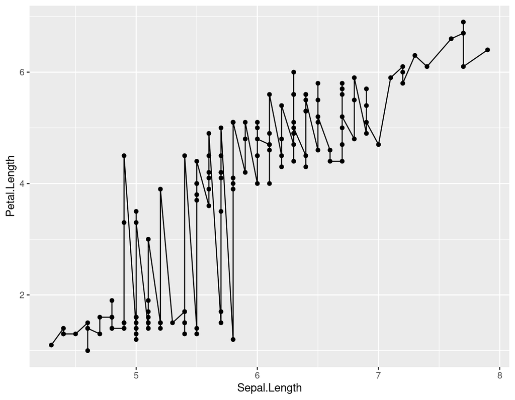

```r
ggplot(iris, aes(Sepal.Length, Petal.Length)) + geom_point() + geom_line()
```

Tampoco son muy útiles la lineas en este gráfico.

Otra geometría o **geom_()** que se usa mucho es `geom_smooth()`. Probémosla:

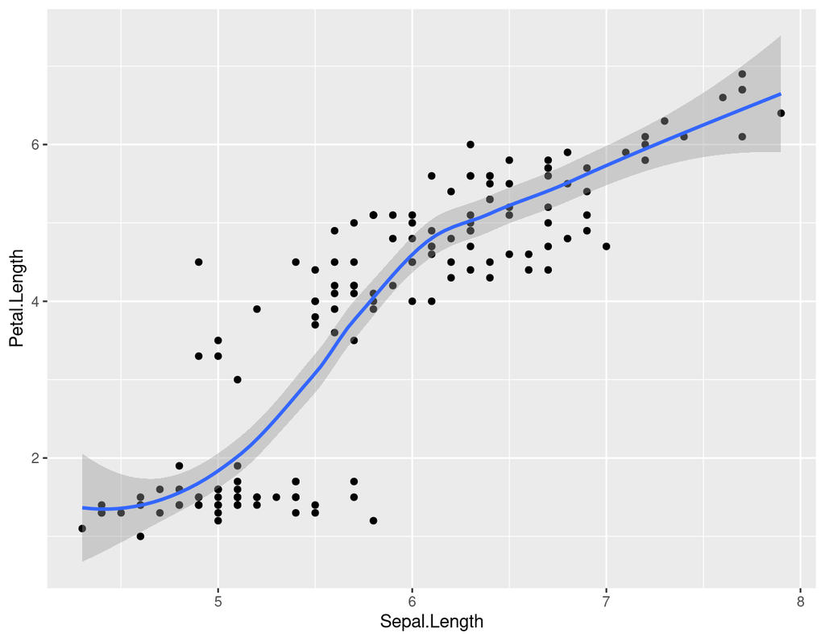

```r
ggplot(iris, aes(Sepal.Length, Petal.Length)) + geom_point() +  geom_smooth()
```

Del gráfico puede inferirse que hay una relación, no lineal, pero sí directa o positiva entre la longitud del sépalo y del pétalo; pero también se aprecia que hay al menos dos grupos distintos de lirios. Hay un grupo de observaciones cuyo pétalo parece ser claramente menor que el del resto de lirios. Veamos si esto se debe o esta asociado al tipo de lirio, recuerda que hay 3 tipos de lirios, asociados a la variable `iris$Species`. Para verlo en nuestro gráfico lo que vamos a hacer es asociar/mapear la variable `Species` con la **aes**thetics color:

```r
ggplot(iris, aes(Sepal.Length, Petal.Length, color = Species)) + geom_point()
```

[output not shown]

Pues parece que sí, que la especie de lirios “setosa” es más pequeña, al menos en longitud, del sépalo, pero sobre todo del pétalo.

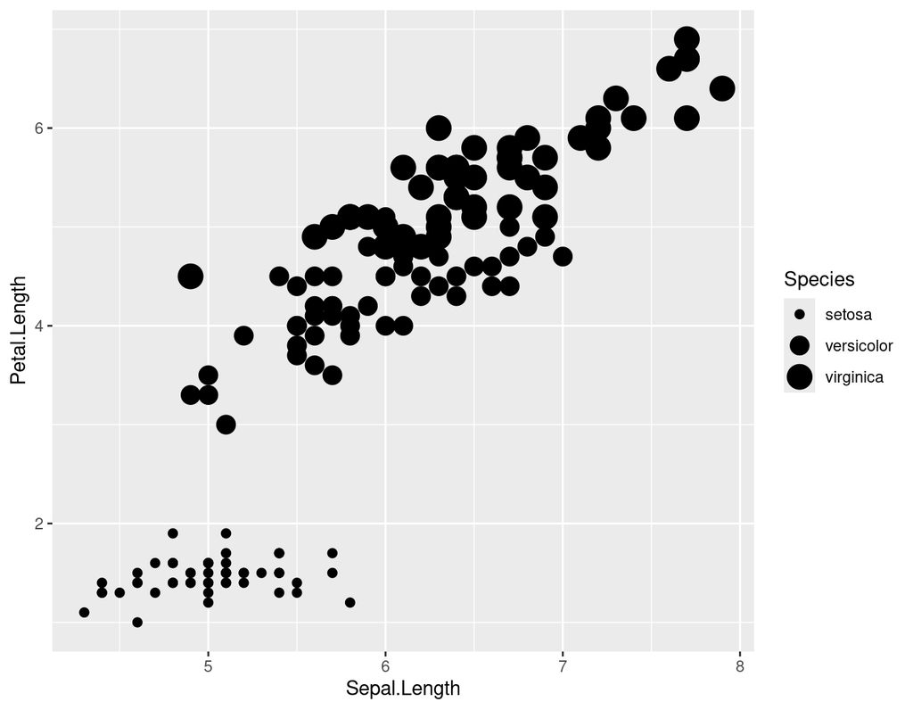

```r
ggplot(iris, aes(Sepal.Length, Petal.Length, size = Species)) + geom_point()
```

También podemos asociar la variable `Species` a la estética “forma”(shape). Lo hacemos en la expresión de más abajo. Como veis, ahora las diferencias entre especies de lirios no se aprecian tan bien como cuando usábamos `color = Species`

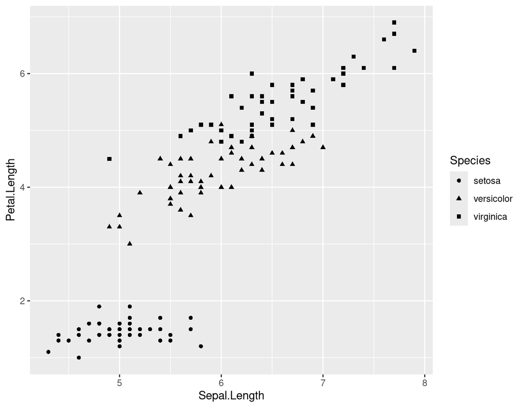

```r
ggplot(iris, aes(Sepal.Length, Petal.Length, shape = Species)) + geom_point()
```

Os va a costar hacer gráficos, normal!!!, pero espero que la idea principal ya la tengáis. Lo que pasa es que no os he contado todo, en realidad es un poco más complejo y versátil. Lo medio explico en el siguiente apartado.

### Más ideas sobre ggplot2

Ya tenéis las ideas principales para hacer gráficos con `ggplot2`, pero no os lo he contado todo, tampoco lo voy a hacer ahora, pero si contaré las cosas de una forma diferente para que tengáis más flexibilidad/versatilidad a la hora de hacer gráficos. Si queréis saber toda la verdad[^3] tendréis que ir al libro de Hadley, concretamente [aquí](https://ggplot2-book.org/layers.html).

La forma que os he contado de hacer gráficos `ggplot2` es la que veréis habitualmente, yo también hago mis gráficos así, solo que para entender mejor el funcionamiento, la sintaxis de `ggplot2`, os lo tengo que contar otra vez de una forma un poco diferente o ampliada.

Un gráfico de ggplot2 se inicia llamando a la función `ggplot()` eso es cierto y también es verdad que generalmente dentro de `ggplot()` se indica el data.frame que vas a utilizar y con `aes()` que variables vas a usar y con que elementos visuales o estéticos quieres asociar cada una de la variables que vas a utilizar[^4]. Correcto, pero …. en realidad un gráfico ggplot2 se hace por capas, cada capa se especifica con una función de la familia `geom_xx()`, así que en realidad los datos y las `aes()` se “deberían” especificar dentro de la función geom_xx()`.

Parece un poco de lío pero en cuanto lo entiendas es muy fácil y te puede dar más flexibilidad a la hora de hacer tus gráficos. Empecemos: ¿recuerdas que hacen las lineas/expresiones de abajo?

```r
ggplot(iris, aes(Sepal.Length, Petal.Length)) + geom_point()
ggplot(iris, aes(Sepal.Length, Petal.Length)) + geom_point() + geom_line()
```

Podemos pensar que las funciones que hacen la representación gráfica realmente son las `geom_xx()`; es ahí donde deberíamos especificar los datos y variables/estéticas que queremos usar, pero si no las especificamos en la función `geom()`, entonces, ggplot2 mirará a ver si existen, si están especificados, dentro de `ggplot()`.

Ahora que ya sabemos el funcionamiento básico de `ggplot2`, veamos algunos detalles mediante algunos ejemplos. Hasta ahora hemos especificado el data.frame que queremos graficar con `ggplot(data = my_df)` o con `ggplot(my_df)` y las variables que queremos ver, y a que propiedad estética queremos asociarla, con la función `aes()` **dentro de `ggplot()`**. Si lo hacemos así, todos los `geoms_xx()` que utilicemos compartirán el conjunto de datos y las variables/estéticas a mappear y mostrar; pero a veces, en gráficos más complejos podemos querer hacer que cada `geom_xx()` muestre datos y/o variables distintas.

Entender que cada `geom_xx()` puede estar asociado a distintos data.frames y/o variables es importante para tener más versatilidad con `ggplot2`.Por ejemplo, las siguientes tres expresiones hacen el mismo gráfico. Se suele utilizar la primera expresión, pero la segunda y tercera expresiones son “más flexibles”, aunque es verdad que si sólo se utiliza un `geom_xx()` no ganamos nada por usar la segunda o tercera expresión, pero no será el caso si en nuestro gráfico necesitamos usar varios `geom_xx()`

```r
ggplot(iris, aes(Sepal.Length, Petal.Length)) + geom_point()

ggplot(iris) + geom_point(aes(Sepal.Length, Petal.Length))

ggplot() + geom_point(data = iris, aes(Sepal.Length, Petal.Length))
```

Fíjate, como detalle, pero importante, que si utilizas la tercera expresión; es decir, si especificas los datos dentro de la función `geom_xx()`, es necesario poner el nombre del argumento ; es decir, debes poner `data = iris`, no puedes poner solo `iris`. Yo me olvido siempre de este detalle[^5].

[figure not shown]

En este caso (como el gráfico solo tiene una capa, como sólo usamos un `geom(_xx)`) no ganamos nada por usar la segunda o tercera expresión; PERO, cuando usemos varios `geom_xx()` esto nos dará muchas posibilidades para nuestro gráfico.

Intenta descubrir las diferencias y funcionamiento de las 3 siguientes instrucciones. Recuerda que puedes correr las instrucciones en R para ver que hacen exactamente.

```r
ggplot(iris, aes(Sepal.Length, Petal.Length, color = Species)) + geom_point() + geom_smooth()
ggplot(iris, aes(Sepal.Length, Petal.Length)) + geom_point(aes(color = Species)) + geom_smooth()
ggplot(iris, aes(Sepal.Length, Petal.Length)) + geom_point() + geom_smooth(aes(color = Species))
```

Veámoslas una a una:

1. Los datos y las 3 variables/estéticas dentro de ggplot()

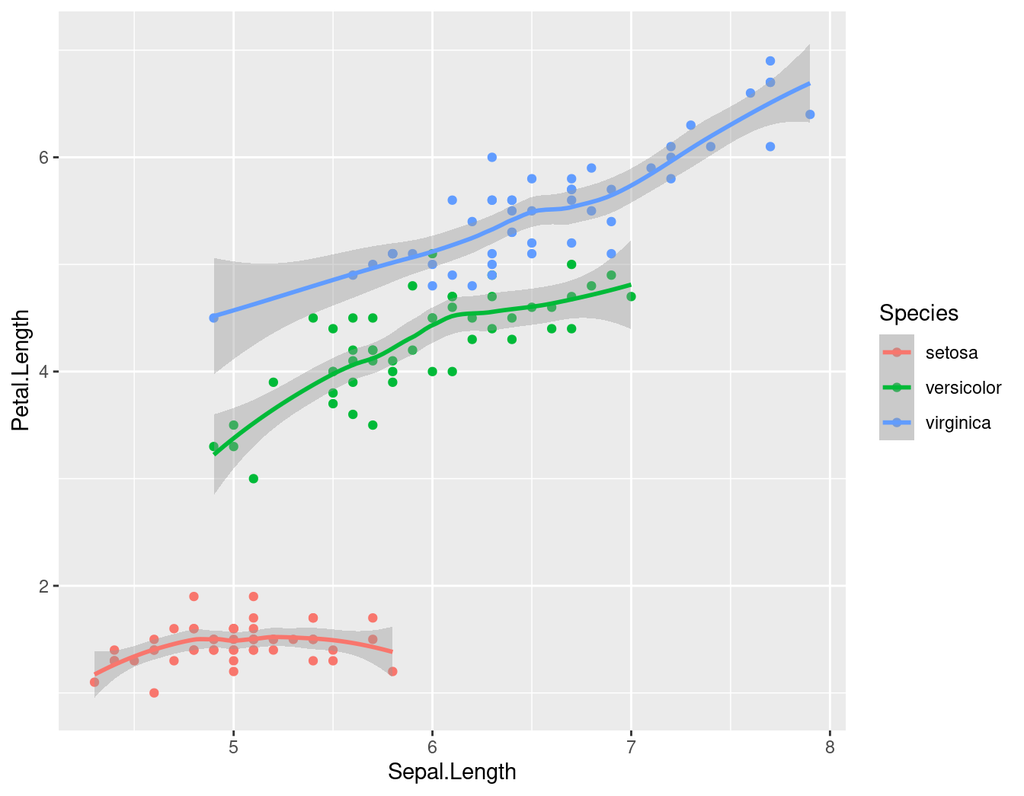

```r
ggplot(iris, aes(Sepal.Length, Petal.Length, color = Species)) + geom_point() + geom_smooth()
```

En este caso los 2 geoms comparten el conjunto de datos (iris) y las variables/estéticas a graficar

2. Los datos y 2 variables/estéticas dentro de ggplot(), pero una tercera variable (Species), asociada a la estética color, aparece solamente en `geom_point()`

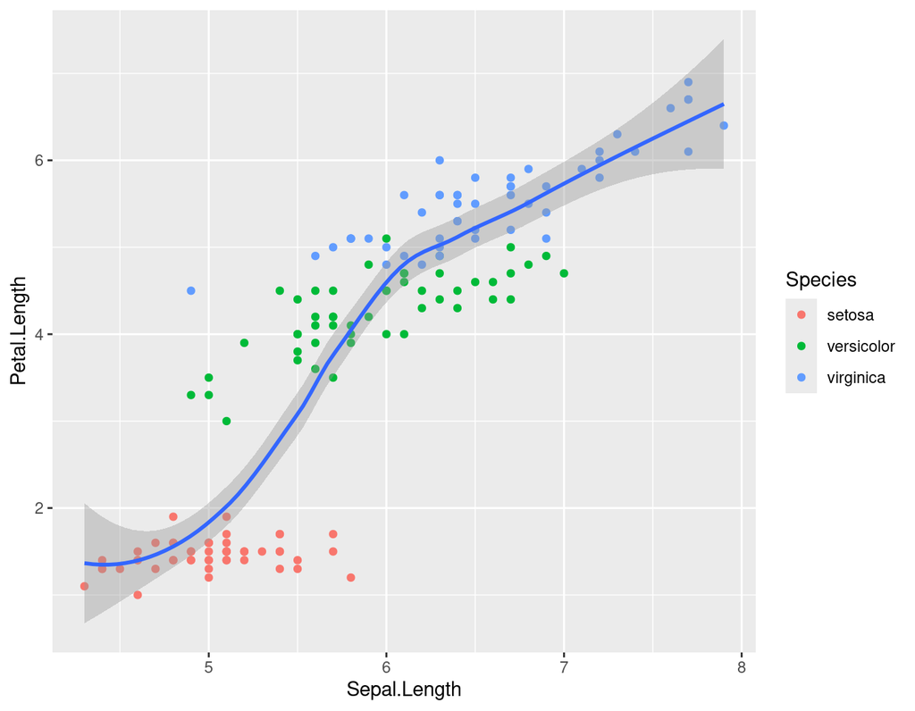

```r
ggplot(iris, aes(Sepal.Length, Petal.Length)) + geom_point(aes(color = Species)) + geom_smooth()
```

3. Los datos y 2 variables/estéticas dentro de ggplot(), pero una tercera variable (Species), asociada a la estética color, aparece solamente en `geom_smooth()`

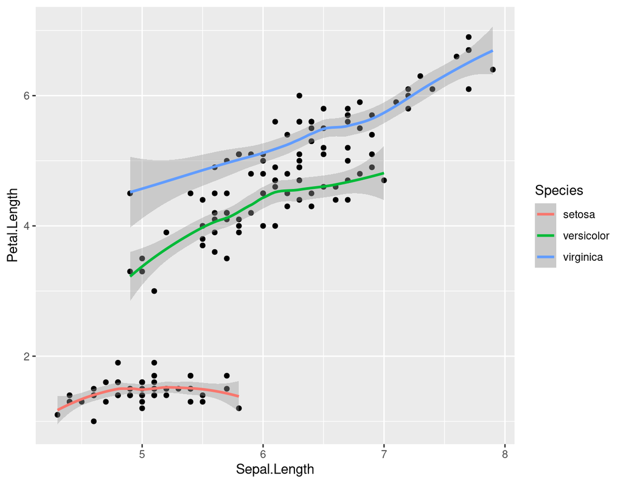

```r
ggplot(iris, aes(Sepal.Length, Petal.Length)) + geom_point() + geom_smooth(aes(color = Species))
```

Espero, seguro!!, que te has dado cuenta de que si especificas el data.frame y las variables/estéticas dentro de `ggplot()` esto afectará a todos los geoms del gráfico; pero lo que se especifique dentro de un `geom_xx()` solo afecta a esa geometría.

**Otro ejemplo** para entenderlo, ¿por qué no funciona la siguiente expresión?

```r
ggplot(iris) + geom_point(aes(Sepal.Length, Petal.Length)) + geom_smooth(aes(color = Species))
```

Pues porque para poder representar la linea suavizada se utiliza `geom_smooth()`, y `geom_smooth()` necesita como mínimo tener variables asociadas a las estéticas x e y. Como veis, dentro de `geom_smooth()` solo hemos especificado la estética “color” y tampoco hemos especificado en la función `ggplot()` que variables se asocian con x e y. Por lo tanto, `geom_smooth()` no puede hacer su trabajo, le faltan los “datos” de x e y para calcular/obtener la linea suavizada.

Vamos con **otros ejemplos**. La siguientes expresiones tampoco funcionarán[^6] si intentáis correrlas en vuestro ordenador. ¿Por qué?

```r
ggplot() + geom_point(data = iris, aes(Sepal.Length, Petal.Length)) + geom_line(aes(Sepal.Length, Petal.Length))

ggplot(aes(Sepal.Length, Petal.Length)) + geom_point(data = iris) + geom_line()

ggplot() + geom_point(data = iris, aes(Sepal.Length, Petal.Length)) + geom_line()
```

**Otro ejemplo:** hagamos algo más marciano/complicado. Supón que quieres hacer un gráfico diferenciando los puntos por color para las tres especies de lirios, pero quieres que solo se vea la linea suavizada para las dos especies más grandes (virginica y versicolor). Los lirios más pequeños son los de la clase setosa. Igual se puede hacer de otra forma pero la que me viene a la cabeza es hacer lo siguiente:

Primero, crear un dataset que sólo contenga a los lirios grandes, los de las especies virginica y versicolor.

```r
iris2 <- iris %>% filter(Species != "setosa") #- me quedo con los lirios que no son de clase "setosa"
```

Para después hacer el gráfico con cualquiera de las 2 expresiones siguientes. Prefiero la segunda porque hay que teclear/escribir menos, pero puede que sea más didáctica la primera.

```r
ggplot() + geom_point(data = iris, aes(Sepal.Length, Petal.Length, color = Species)) + geom_smooth(data = iris2, aes(Sepal.Length, Petal.Length) )

ggplot(iris, aes(Sepal.Length, Petal.Length)) + geom_point(aes(color = Species)) + geom_smooth(data = iris2)
```

**Otro ejemplo** más: ¿y si quisiéramos que las 2 especies grandes se representen con el mismo color? Hay varias soluciones, una de las más marcianas es la que propongo abajo. Es una solución rara, pero creo que os ayudará a entender `ggplot2`

Primero voy a crear un nuevo data.frame sólo con las observaciones de los lirios pequeños, los de la clase setosa.

```r
iris_setosa <- iris %>% filter(Species == "setosa") #- me quedo con los lirios pequeños, los de clase "setosa"
```

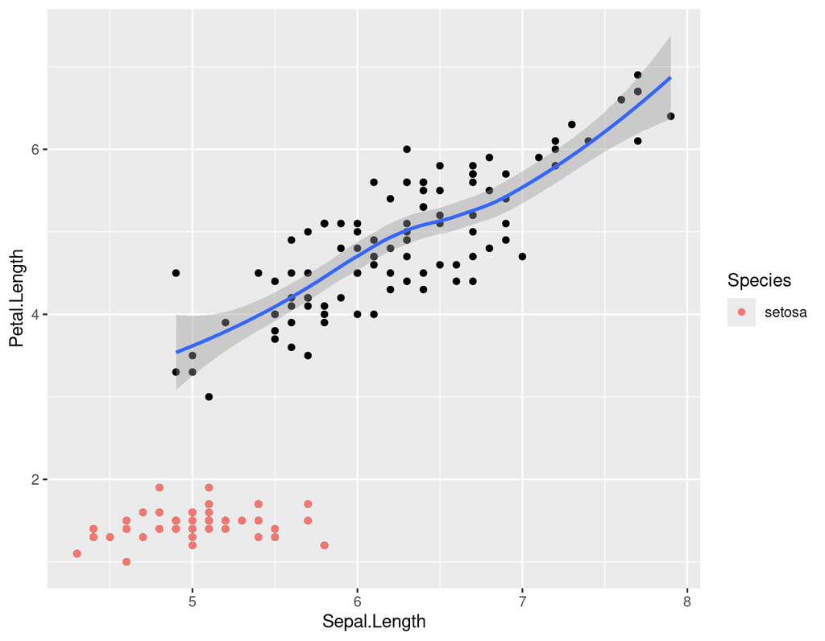

```r
ggplot(iris, aes(Sepal.Length, Petal.Length)) + geom_point() + geom_point(data = iris_setosa, aes(color = Species)) + geom_smooth(data = iris2,aes(Sepal.Length, Petal.Length) )
```

Otra solución, quizás más lógica, consiste en primero agrupar las 2 especies de lirios grandes (versicolor y virginica) en una sola clase.

```r
iris_solo_2_clases <- iris %>% mutate(Species_2 = ifelse(Species %in% c("versicolor", "virginica"), "versi_virgi", "setosa"))
```

Para después hacer el gráfico. Además el gráfico lo podemos hacer al menos de 2 maneras, la segunda mucho mejor, la primera expresión es un poco enrevesada:

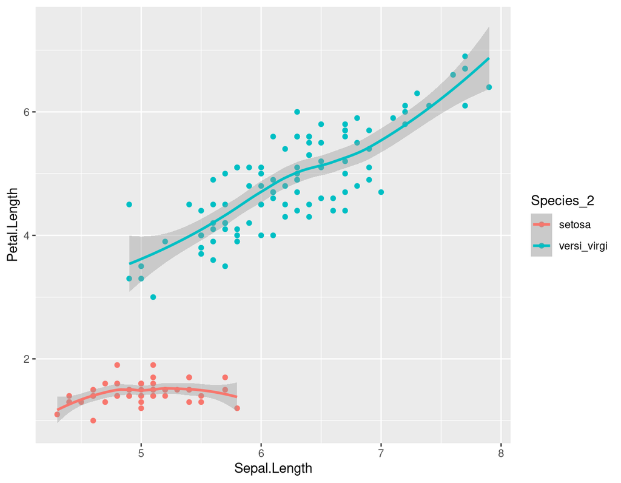

```r
ggplot(iris, aes(Sepal.Length, Petal.Length)) + geom_point() + geom_point(data = iris_setosa, aes(color = Species)) + geom_smooth(data = iris_solo_2_clases,aes(Sepal.Length, Petal.Length, color = Species_2) )

ggplot(iris_solo_2_clases, aes(Sepal.Length, Petal.Length, color = Species_2)) + geom_point() + geom_smooth()
```

Como veis, en `ggplot2` hay varias maneras de hacer el mismo gráfico. Esto al principio puede abrumar/molestar, pero muestra la flexibilidad de la sintaxis.

Para ir acabando con la “filosofía”/sintaxis/gramática de `ggplot2` intenta imaginar que gráficos hacen las 6 expresiones de más abajo.

Si no puedes, recuerda que siempre puedes ejecutar las ordenes en el ordenador. Fíjate sobre todo en la tercera expresión

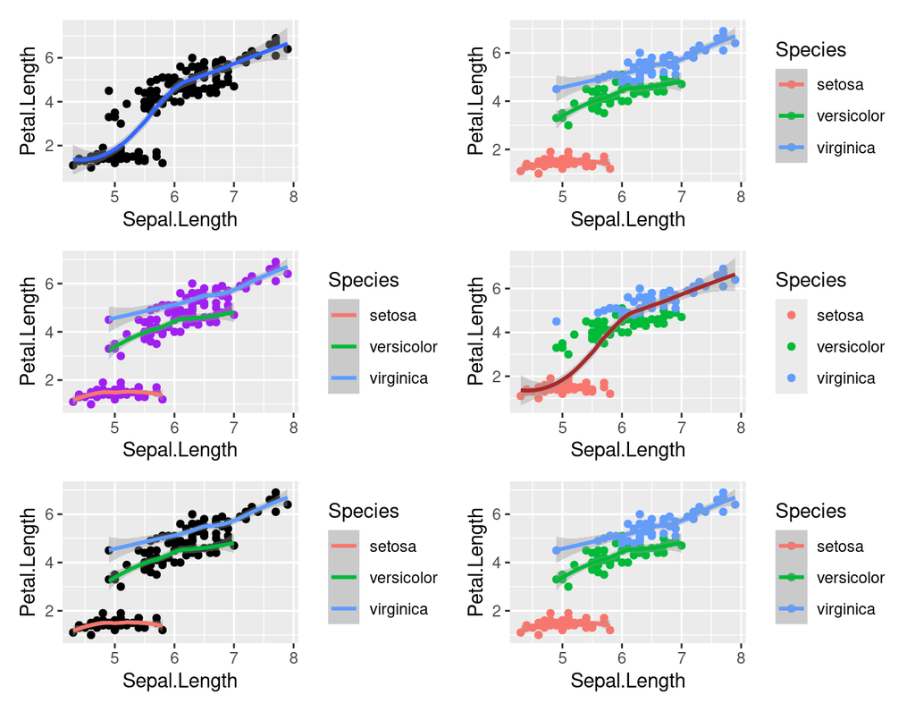

```r
ggplot(iris, aes(Sepal.Length, Petal.Length)) + geom_point() + geom_smooth()
ggplot(iris, aes(Sepal.Length, Petal.Length, color = Species)) + geom_point() + geom_smooth()
ggplot(iris, aes(Sepal.Length, Petal.Length, color = Species)) + geom_point(color = "purple") + geom_smooth()

ggplot(iris, aes(Sepal.Length, Petal.Length, color = Species)) + geom_point() + geom_smooth(color = "brown")
ggplot(iris, aes(Sepal.Length, Petal.Length)) + geom_point() + geom_smooth(aes(color = Species))
ggplot(iris) + geom_point(aes(Sepal.Length, Petal.Length, color = Species) ) + geom_smooth(aes(Sepal.Length, Petal.Length, color = Species))
```

En la tercera expresión se especifica `color = Species` dentro de `aes()` en `ggplot()`, así que, de momento, todos los geoms del gráfico deberían diferenciar por especies de lirios usando el color, PERO, después se vuelve a usar el argumento `color` dentro de `geom_point()`, pero fíjate que no va dentro de de `aes()`, va fuera. Concretamente hacemos lo siguiente: `geom_point(color = "purple")`; es decir, para la capa de puntos, y solo para la capa de puntos que se crea con `geom_point()`, estamos asociando la estética color, no a una variable, sino a un color fijo. Sin embargo, para la otra capa del gráfico, la que resulta de usar `geom_smooth()` sigue siendo valido que la estética color está asociada a la variable Species.

Un detalle: imagina que en un gráfico en el que has fijado 3 estéticas dentro de `ggplot(aes())`. En principio las 3 estéticas afectarán a todos los `geom_xx()` que utilices en tu gráfico, pero si quisieras que, por ejemplo, la estética color no afectase a un geom concreto, podrías hacer lo siguiente: `geom_xx(aes(color = NULL))`.

Como puedes imaginar, aún tenemos que ver más elementos de `ggplot2`. Como mínimo los títulos y leyendas, los ejes, el tema, coordenadas, etc… vamos a ello!!

## 3. Elementos de un ggplot

Ya hemos presentado los principales elementos de los gráficos hechos con `ggplot2`, los que tienen que ver con la representación de las variables. Pero es evidente que un gráfico tiene muchos más elementos, y lógicamente hay que conocerlos un poco para poder ajustar los gráficos a nuestras necesidades y mejorar la calidad de nuestros gráficos.

Ejemplos de otros elementos son: títulos del gráfico y de los ejes, “theme” del gráfico, small multiples o faceting, anotaciones etc…

En está sección iremos más rápido. Se presentarán solamente algunos ejemplos, conceptos y/o aclaraciones. Si necesitas profundizar más en estos elementos, puedes acudir a la [referencia oficial](https://ggplot2.tidyverse.org/reference/index.html#section-layer-geoms) de `ggplot2` o al [bookdown de ggplot2](https://ggplot2-book.org/).

Ya dijimos que los gráficos ggplot se componen de capas o layers. Para nosotros, hasta ahora, una capa estaba compuesta de 3 elementos:

- un conjunto de datos
- un conjunto de variables mapeadas con `aes()` a propiedades estéticas
- una geometría, con `geom_xx()`

Es evidente que en todos los geoms no se pueden especificar todas las características estéticas. Por ejemplo si usas `geom_point` no podrás especificar la anchura o el tipo de las lineas, porque no estás usando lineas sino puntos. Para ver que estéticas admite cada geom tendrás que mirar la ayuda de cada geom. Al final de [este post](https://www.yihanwu.ca/post/geoms-and-aesthetic-parameters/) tienen un gráfico interactivo con el que se puede ver fácilmente que características estéticas admite cada geom. Por ejemplo `geom_bar()`, que sirve para hacer gráficos de barras, no admite mappear variables al eje Y, ya que en el eje Y se visualizan/mapean las frecuencias absolutas o relativas de la variable que se representa en el eje X.

Esto es lo básico que hay que saber, pero en realidad, una capa necesita de dos elementos más: una **stat** (o transformación estadística) y una **posición**. Estos dos últimos elementos son necesarios pero la verdad es que podríamos seguir haciendo gráficos con `ggplot2` sin conocerlos. ¿Por qué? Pues porque si en una capa no los especificamos, lo hace `ggplot2` por nosotros. Lo ha estado haciendo hasta ahora en todos los gráficos que llevamos hechos. Pero claro, saber como utilizar estos elementos nos dará más flexibilidad a la hora de hacer ggplots.

Generalmente las capas se van añadiendo con la familia de funciones `geom_xx()`, **PERO** también se pueden añadir capas con otra familia de funciones `stat_xx()`.

Aparte de estos cinco elementos (datos, aes(), geom, stat y posición) los gráficos ggplot pueden tener más elementos. Veámoslos uno a uno.

### 3.1 Títulos del gráfico

Es evidente que un gráfico para ser efectivo y mostrar su mensaje con claridad debe tener un título y/o subtítulo ilustrativo y debe mostrar información relevante sobre que variables se grafican los ejes X e Y. Este tipo de elementos pueden modificarse de varias maneras, pero nos centraremos en la función `labs()`.

Fíjate que con la función `labs()`, de labels, podemos cambiar los títulos del gráfico, de los ejes y también de las leyendas.

En los títulos (tanto del gráfico, como de los ejes y leyendas) también se pueden cambiar otras características; por ejemplo, cambiar el tamaño, la fuente o el color, pero eso será tarea de otra función de `ggplot2`: del grupo de funciones `theme_()`. Pero el tema o theme de los gráficos lo veremos en el siguiente apartado.

Tomemos el siguiente gráfico como referencia y sobre él iremos añadiendo elementos:

```r
p <- ggplot(iris, aes(Sepal.Length, Petal.Length, color = Species)) + geom_point()
p
```

Con la función `labs()` podemos añadirle un título, subtitulo, pie de gráfico o *caption*. También podemos cambiar el título de los ejes X e Y, así como también el titulo de la leyenda para `color`, o para otras estéticas que utilicemos en el gráfico.

Es suficiente con ver un ejemplo:

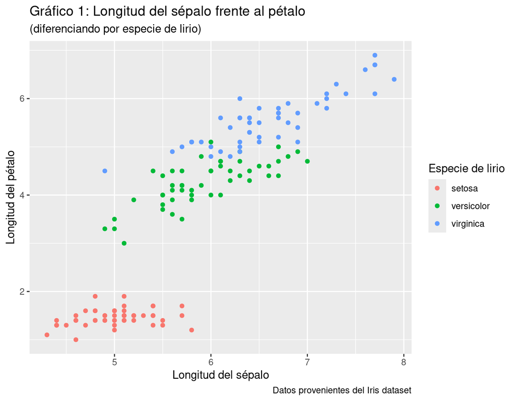

```r
p + labs(title = "Gráfico 1: Longitud del sépalo frente al pétalo",
       subtitle = "(diferenciando por especie de lirio)",
       caption = "Datos provenientes del Iris dataset",
       x = "Longitud del sépalo",
       y = "Longitud del pétalo",
       color = "Especie de lirio")
```

Si quisieras eliminar completamente los **títulos** del eje X podrías hacerlo en el anterior chunk fijando `x = NULL` dentro de la función `labs()`.

En lugar de usar la función `labs()`, también podemos utilizar las funciones auxiliares `xlab()` e `ylab()`

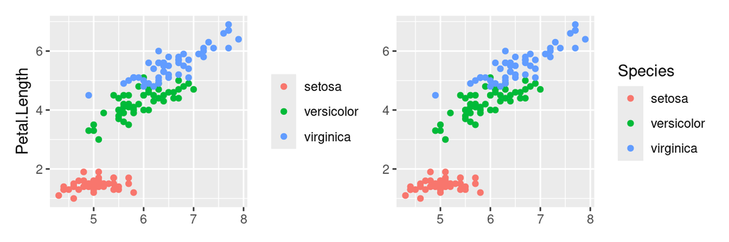

```r
p + labs(color = NULL, x = NULL)  #- borra el título de la leyenda y del eje X
p + xlab(NULL) + ylab(NULL)       #- elimina títulos de los ejes X e Y
```